Back [Original](https://pcdealcheck.com/)

# Show HN: I built a tool that prices a prebuilt PC part by part

Working now · Public beta

PC Deal Check makes checking a computer’s asking price quick and easy, whether you understand hardware or not.

Free for visitors in the United States. US retailer listings and prices. No account needed.

A clear second opinion. No prompts or hardware expertise needed.

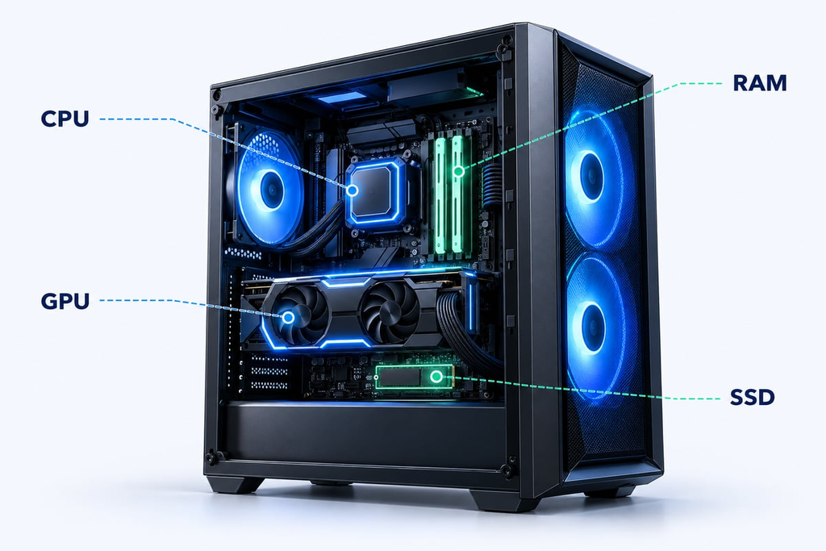

01 · BRING THE DEAL

## Start with a listing

Paste a retailer’s product link or upload a photo of the price and specs. AI helps read the listing and identify the main parts.

02 · SEE THE VALUE

## Understand the price

Our custom pricing engine compares the asking price with market-based component estimates to determine the deal’s grade.

03 · MAKE YOUR CALL

## Get a clear report

Review the grade, dated component estimates and price-check links. Share, email or print your report before deciding.

A real check · November 1, 2026

## See what a report looks like.

A PowerSpec G531 listed at $1,399.99 received an A against a parts estimate of about $1,569. See the identified specs, price dates and comparison.

Past example. Out of stock when checked. Not a current offer.

[View sample report →](https://pcdealcheck.com/sample-report)

## Try it with us.

Free for visitors in the United States. US retailer listings and prices. No account needed. PC Deal Check is in beta. Features, reports and scoring may change as we improve the service. Questions or feedback? Email contact@pcdealcheck.com.

[Check a PC →](https://app.pcdealcheck.com/check)